# Risk Factor Analysis

## Outcome Variable

**Outcome Variable:** y_rate_len

## Predictor Variables

**Intervention Variable:** nrooms

**Adjustment Set:**

- arm
- sex
- W_mage
- meducyrs
- feducyrs
- hhwealth_quart
- hfoodsec
- W_mhtcm
- W_nchldlt5
- W_parity
- impfloor
- impsan
- safeh20
- delta_W_mage
- delta_meducyrs
- delta_feducyrs
- delta_hhwealth_quart
- delta_hfoodsec
- delta_W_mhtcm
- delta_W_nchldlt5
- delta_W_parity
- delta_impfloor
- delta_impsan
- delta_safeh20

## Stratifying Variables

The analysis was stratified on these variable(s):

- agecat
- studyid
- country

## Data Summary

| agecat | studyid | country | nrooms | n_cell | n |
| --- | --- | --- | --- | --- | --- |
| 0-3 months | ki0047075b-MAL-ED | BANGLADESH | 1 | 149 | 237 |
| 0-3 months | ki0047075b-MAL-ED | BANGLADESH | 2 | 49 | 237 |
| 0-3 months | ki0047075b-MAL-ED | BANGLADESH | 3 | 28 | 237 |
| 0-3 months | ki0047075b-MAL-ED | BANGLADESH | 4+ | 11 | 237 |
| 0-3 months | ki1017093b-PROVIDE | BANGLADESH | 1 | 452 | 634 |
| 0-3 months | ki1017093b-PROVIDE | BANGLADESH | 2 | 101 | 634 |
| 0-3 months | ki1017093b-PROVIDE | BANGLADESH | 3 | 59 | 634 |
| 0-3 months | ki1017093b-PROVIDE | BANGLADESH | 4+ | 22 | 634 |
| 0-3 months | ki1017093c-NIH-Crypto | BANGLADESH | 1 | 344 | 720 |
| 0-3 months | ki1017093c-NIH-Crypto | BANGLADESH | 2 | 183 | 720 |
| 0-3 months | ki1017093c-NIH-Crypto | BANGLADESH | 3 | 102 | 720 |
| 0-3 months | ki1017093c-NIH-Crypto | BANGLADESH | 4+ | 91 | 720 |
| 0-3 months | kiGH5241-JiVitA-3 | BANGLADESH | 1 | 12473 | 20026 |
| 0-3 months | kiGH5241-JiVitA-3 | BANGLADESH | 2 | 5183 | 20026 |
| 0-3 months | kiGH5241-JiVitA-3 | BANGLADESH | 3 | 1687 | 20026 |
| 0-3 months | kiGH5241-JiVitA-3 | BANGLADESH | 4+ | 683 | 20026 |
| 0-3 months | kiGH5241-JiVitA-4 | BANGLADESH | 1 | 1111 | 1805 |
| 0-3 months | kiGH5241-JiVitA-4 | BANGLADESH | 2 | 452 | 1805 |
| 0-3 months | kiGH5241-JiVitA-4 | BANGLADESH | 3 | 172 | 1805 |
| 0-3 months | kiGH5241-JiVitA-4 | BANGLADESH | 4+ | 70 | 1805 |
| 0-3 months | ki0047075b-MAL-ED | BRAZIL | 1 | 3 | 174 |
| 0-3 months | ki0047075b-MAL-ED | BRAZIL | 2 | 19 | 174 |
| 0-3 months | ki0047075b-MAL-ED | BRAZIL | 3 | 50 | 174 |
| 0-3 months | ki0047075b-MAL-ED | BRAZIL | 4+ | 102 | 174 |
| 0-3 months | ki0047075b-MAL-ED | INDIA | 1 | 73 | 194 |
| 0-3 months | ki0047075b-MAL-ED | INDIA | 2 | 68 | 194 |
| 0-3 months | ki0047075b-MAL-ED | INDIA | 3 | 31 | 194 |
| 0-3 months | ki0047075b-MAL-ED | INDIA | 4+ | 22 | 194 |
| 0-3 months | ki1000108-CMC-V-BCS-2002 | INDIA | 1 | 33 | 87 |
| 0-3 months | ki1000108-CMC-V-BCS-2002 | INDIA | 2 | 32 | 87 |

[output cut: 221 more lines]

The following strata were considered:

- agecat: 0-3 months, studyid: ki0047075b-MAL-ED, country: BANGLADESH
- agecat: 0-3 months, studyid: ki0047075b-MAL-ED, country: BRAZIL
- agecat: 0-3 months, studyid: ki0047075b-MAL-ED, country: INDIA
- agecat: 0-3 months, studyid: ki0047075b-MAL-ED, country: NEPAL
- agecat: 0-3 months, studyid: ki0047075b-MAL-ED, country: PERU
- agecat: 0-3 months, studyid: ki0047075b-MAL-ED, country: SOUTH AFRICA
- agecat: 0-3 months, studyid: ki0047075b-MAL-ED, country: TANZANIA, UNITED REPUBLIC OF
- agecat: 0-3 months, studyid: ki1000108-CMC-V-BCS-2002, country: INDIA
- agecat: 0-3 months, studyid: ki1000108-IRC, country: INDIA
- agecat: 0-3 months, studyid: ki1017093b-PROVIDE, country: BANGLADESH
- agecat: 0-3 months, studyid: ki1017093c-NIH-Crypto, country: BANGLADESH
- agecat: 0-3 months, studyid: ki1114097-CONTENT, country: PERU
- agecat: 0-3 months, studyid: ki1135781-COHORTS, country: INDIA
- agecat: 0-3 months, studyid: kiGH5241-JiVitA-3, country: BANGLADESH
- agecat: 0-3 months, studyid: kiGH5241-JiVitA-4, country: BANGLADESH
- agecat: 12-24 months, studyid: ki0047075b-MAL-ED, country: BANGLADESH
- agecat: 12-24 months, studyid: ki0047075b-MAL-ED, country: BRAZIL
- agecat: 12-24 months, studyid: ki0047075b-MAL-ED, country: INDIA
- agecat: 12-24 months, studyid: ki0047075b-MAL-ED, country: NEPAL
- agecat: 12-24 months, studyid: ki0047075b-MAL-ED, country: PERU
- agecat: 12-24 months, studyid: ki0047075b-MAL-ED, country: SOUTH AFRICA
- agecat: 12-24 months, studyid: ki0047075b-MAL-ED, country: TANZANIA, UNITED REPUBLIC OF
- agecat: 12-24 months, studyid: ki1000108-CMC-V-BCS-2002, country: INDIA
- agecat: 12-24 months, studyid: ki1000108-IRC, country: INDIA
- agecat: 12-24 months, studyid: ki1017093b-PROVIDE, country: BANGLADESH
- agecat: 12-24 months, studyid: ki1017093c-NIH-Crypto, country: BANGLADESH
- agecat: 12-24 months, studyid: ki1113344-GMS-Nepal, country: NEPAL
- agecat: 12-24 months, studyid: ki1114097-CONTENT, country: PERU
- agecat: 12-24 months, studyid: ki1135781-COHORTS, country: INDIA
- agecat: 12-24 months, studyid: kiGH5241-JiVitA-3, country: BANGLADESH
- agecat: 12-24 months, studyid: kiGH5241-JiVitA-4, country: BANGLADESH
- agecat: 3-6 months, studyid: ki0047075b-MAL-ED, country: BANGLADESH
- agecat: 3-6 months, studyid: ki0047075b-MAL-ED, country: BRAZIL
- agecat: 3-6 months, studyid: ki0047075b-MAL-ED, country: INDIA
- agecat: 3-6 months, studyid: ki0047075b-MAL-ED, country: NEPAL
- agecat: 3-6 months, studyid: ki0047075b-MAL-ED, country: PERU
- agecat: 3-6 months, studyid: ki0047075b-MAL-ED, country: SOUTH AFRICA
- agecat: 3-6 months, studyid: ki0047075b-MAL-ED, country: TANZANIA, UNITED REPUBLIC OF
- agecat: 3-6 months, studyid: ki1000108-CMC-V-BCS-2002, country: INDIA
- agecat: 3-6 months, studyid: ki1000108-IRC, country: INDIA
- agecat: 3-6 months, studyid: ki1017093b-PROVIDE, country: BANGLADESH
- agecat: 3-6 months, studyid: ki1017093c-NIH-Crypto, country: BANGLADESH
- agecat: 3-6 months, studyid: ki1113344-GMS-Nepal, country: NEPAL
- agecat: 3-6 months, studyid: ki1114097-CONTENT, country: PERU
- agecat: 3-6 months, studyid: ki1135781-COHORTS, country: INDIA
- agecat: 3-6 months, studyid: kiGH5241-JiVitA-3, country: BANGLADESH
- agecat: 3-6 months, studyid: kiGH5241-JiVitA-4, country: BANGLADESH
- agecat: 6-12 months, studyid: ki0047075b-MAL-ED, country: BANGLADESH
- agecat: 6-12 months, studyid: ki0047075b-MAL-ED, country: BRAZIL
- agecat: 6-12 months, studyid: ki0047075b-MAL-ED, country: INDIA
- agecat: 6-12 months, studyid: ki0047075b-MAL-ED, country: NEPAL
- agecat: 6-12 months, studyid: ki0047075b-MAL-ED, country: PERU
- agecat: 6-12 months, studyid: ki0047075b-MAL-ED, country: SOUTH AFRICA
- agecat: 6-12 months, studyid: ki0047075b-MAL-ED, country: TANZANIA, UNITED REPUBLIC OF
- agecat: 6-12 months, studyid: ki1000108-CMC-V-BCS-2002, country: INDIA
- agecat: 6-12 months, studyid: ki1000108-IRC, country: INDIA
- agecat: 6-12 months, studyid: ki1017093b-PROVIDE, country: BANGLADESH
- agecat: 6-12 months, studyid: ki1017093c-NIH-Crypto, country: BANGLADESH
- agecat: 6-12 months, studyid: ki1113344-GMS-Nepal, country: NEPAL
- agecat: 6-12 months, studyid: ki1114097-CONTENT, country: PERU
- agecat: 6-12 months, studyid: ki1135781-COHORTS, country: INDIA
- agecat: 6-12 months, studyid: kiGH5241-JiVitA-3, country: BANGLADESH
- agecat: 6-12 months, studyid: kiGH5241-JiVitA-4, country: BANGLADESH

### Dropped Strata

Some strata were dropped due to rare outcomes:

- agecat: 0-3 months, studyid: ki0047075b-MAL-ED, country: BRAZIL
- agecat: 0-3 months, studyid: ki1000108-CMC-V-BCS-2002, country: INDIA
- agecat: 0-3 months, studyid: ki1114097-CONTENT, country: PERU
- agecat: 3-6 months, studyid: ki0047075b-MAL-ED, country: BRAZIL
- agecat: 6-12 months, studyid: ki0047075b-MAL-ED, country: BRAZIL

## Methods Detail

We’re interested in the causal parameters $E[Y_a]$ for all values of $a \in \mathcal{A}$. These parameters represent the mean outcome if, possibly contrary to fact, we intervened to set all units to have $A=a$. Under the randomization and positivity assumptions, these are identified by the statistical parameters $\psi_a=E_W[E_{Y|A,W}(Y|A=a,W)]$. In addition, we’re interested in the mean of $Y$, $E[Y]$ under no intervention (the observed mean). We will estimate these parameters by using SuperLearner to fit the relevant likelihood factors – $E_{Y|A,W}(Y|A=a,W)$ and $p(A=a|W)$, and then updating our likelihood fit using a joint TMLE.

For unadjusted analyses ($W=\{\}$), initial likelihoods were estimated using Lrnr_glm to estimate the simple $E(Y|A)$ and Lrnr_mean to estimate $p(A)$. For adjusted analyses, a small library containing Lrnr_glmnet, Lrnr_xgboost, and Lrnr_mean was used.

Having estimated these parameters, we will then use the delta method to estimate relative risks and attributable risks relative to a prespecified baseline level of $A$.

[output not shown]

# Results Detail

## Results Plots

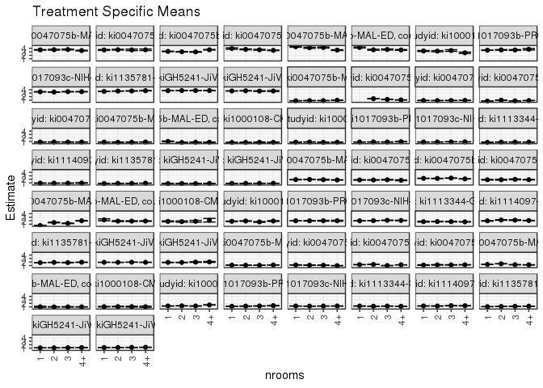

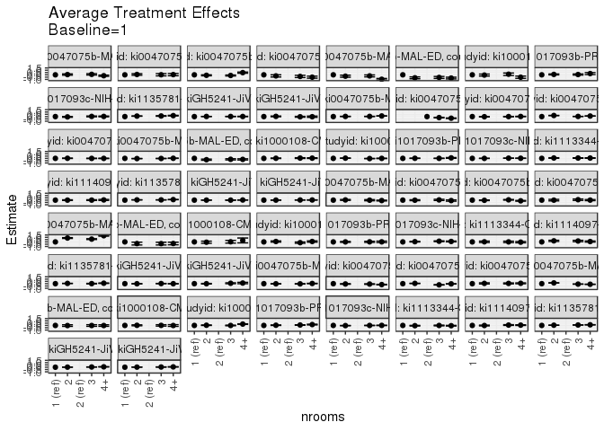

## Results Table

### Parameter: TSM

| agecat | studyid | country | intervention_level | baseline_level | estimate | ci_lower | ci_upper |
| --- | --- | --- | --- | --- | --- | --- | --- |
| 0-3 months | ki0047075b-MAL-ED | BANGLADESH | 1 | NA | 3.5537147 | 3.4730086 | 3.6344208 |
| 0-3 months | ki0047075b-MAL-ED | BANGLADESH | 2 | NA | 3.6088801 | 3.4897518 | 3.7280084 |
| 0-3 months | ki0047075b-MAL-ED | BANGLADESH | 3 | NA | 3.6549637 | 3.5308432 | 3.7790843 |
| 0-3 months | ki0047075b-MAL-ED | BANGLADESH | 4+ | NA | 3.3584420 | 3.2544677 | 3.4624164 |
| 0-3 months | ki0047075b-MAL-ED | INDIA | 1 | NA | 3.5339169 | 3.4074982 | 3.6603355 |
| 0-3 months | ki0047075b-MAL-ED | INDIA | 2 | NA | 3.6095914 | 3.4923833 | 3.7267994 |
| 0-3 months | ki0047075b-MAL-ED | INDIA | 3 | NA | 3.5514591 | 3.3370923 | 3.7658259 |
| 0-3 months | ki0047075b-MAL-ED | INDIA | 4+ | NA | 3.5827554 | 3.3684968 | 3.7970140 |
| 0-3 months | ki0047075b-MAL-ED | NEPAL | 1 | NA | 3.1165014 | 3.0416566 | 3.1913463 |
| 0-3 months | ki0047075b-MAL-ED | NEPAL | 2 | NA | 3.0115207 | 2.9291459 | 3.0938955 |
| 0-3 months | ki0047075b-MAL-ED | NEPAL | 3 | NA | 2.9745359 | 2.8875413 | 3.0615305 |
| 0-3 months | ki0047075b-MAL-ED | NEPAL | 4+ | NA | 3.5940298 | 3.5120175 | 3.6760421 |
| 0-3 months | ki0047075b-MAL-ED | PERU | 1 | NA | 3.9381076 | 3.7352566 | 4.1409586 |
| 0-3 months | ki0047075b-MAL-ED | PERU | 2 | NA | 3.7035348 | 3.5872415 | 3.8198281 |
| 0-3 months | ki0047075b-MAL-ED | PERU | 3 | NA | 3.5852259 | 3.4586742 | 3.7117776 |
| 0-3 months | ki0047075b-MAL-ED | PERU | 4+ | NA | 3.4252167 | 3.3458450 | 3.5045885 |
| 0-3 months | ki0047075b-MAL-ED | SOUTH AFRICA | 1 | NA | 4.4638649 | 4.3224061 | 4.6053237 |
| 0-3 months | ki0047075b-MAL-ED | SOUTH AFRICA | 2 | NA | 4.1632674 | 3.9933301 | 4.3332047 |
| 0-3 months | ki0047075b-MAL-ED | SOUTH AFRICA | 3 | NA | 4.2314240 | 4.0718130 | 4.3910351 |
| 0-3 months | ki0047075b-MAL-ED | SOUTH AFRICA | 4+ | NA | 3.4947542 | 3.3875280 | 3.6019804 |
| 0-3 months | ki0047075b-MAL-ED | TANZANIA, UNITED REPUBLIC OF | 1 | NA | 4.2404207 | 4.0921945 | 4.3886468 |
| 0-3 months | ki0047075b-MAL-ED | TANZANIA, UNITED REPUBLIC OF | 2 | NA | 3.5860838 | 3.4546666 | 3.7175009 |
| 0-3 months | ki0047075b-MAL-ED | TANZANIA, UNITED REPUBLIC OF | 3 | NA | 3.6682761 | 3.5176770 | 3.8188752 |
| 0-3 months | ki0047075b-MAL-ED | TANZANIA, UNITED REPUBLIC OF | 4+ | NA | 3.5311780 | 3.4179572 | 3.6443987 |
| 0-3 months | ki1000108-IRC | INDIA | 1 | NA | 3.2415225 | 3.0997432 | 3.3833018 |
| 0-3 months | ki1000108-IRC | INDIA | 2 | NA | 3.1855292 | 3.0195343 | 3.3515241 |
| 0-3 months | ki1000108-IRC | INDIA | 3 | NA | 3.3741318 | 3.1458269 | 3.6024368 |
| 0-3 months | ki1000108-IRC | INDIA | 4+ | NA | 2.7200318 | 2.5221058 | 2.9179579 |
| 0-3 months | ki1017093b-PROVIDE | BANGLADESH | 1 | NA | 3.4585460 | 3.4121566 | 3.5049354 |
| 0-3 months | ki1017093b-PROVIDE | BANGLADESH | 2 | NA | 3.5469822 | 3.4575254 | 3.6364390 |

[output cut: 201 more lines]

### Parameter: E(Y)

[output not shown]

### Parameter: ATE

| agecat | studyid | country | intervention_level | baseline_level | estimate | ci_lower | ci_upper |
| --- | --- | --- | --- | --- | --- | --- | --- |
| 0-3 months | ki0047075b-MAL-ED | BANGLADESH | 1 | 1 | 0.0000000 | 0.0000000 | 0.0000000 |
| 0-3 months | ki0047075b-MAL-ED | BANGLADESH | 2 | 1 | 0.0551654 | -0.0886321 | 0.1989628 |
| 0-3 months | ki0047075b-MAL-ED | BANGLADESH | 3 | 1 | 0.1012490 | -0.0467135 | 0.2492115 |
| 0-3 months | ki0047075b-MAL-ED | BANGLADESH | 4+ | 1 | -0.1952727 | -0.3266539 | -0.0638914 |
| 0-3 months | ki0047075b-MAL-ED | INDIA | 1 | 1 | 0.0000000 | 0.0000000 | 0.0000000 |
| 0-3 months | ki0047075b-MAL-ED | INDIA | 2 | 1 | 0.0756745 | -0.0944441 | 0.2457930 |
| 0-3 months | ki0047075b-MAL-ED | INDIA | 3 | 1 | 0.0175423 | -0.2305597 | 0.2656442 |
| 0-3 months | ki0047075b-MAL-ED | INDIA | 4+ | 1 | 0.0488385 | -0.1987580 | 0.2964351 |
| 0-3 months | ki0047075b-MAL-ED | NEPAL | 1 | 1 | 0.0000000 | 0.0000000 | 0.0000000 |
| 0-3 months | ki0047075b-MAL-ED | NEPAL | 2 | 1 | -0.1049807 | -0.2132334 | 0.0032720 |
| 0-3 months | ki0047075b-MAL-ED | NEPAL | 3 | 1 | -0.1419655 | -0.2527104 | -0.0312206 |
| 0-3 months | ki0047075b-MAL-ED | NEPAL | 4+ | 1 | 0.4775283 | 0.3534194 | 0.6016372 |
| 0-3 months | ki0047075b-MAL-ED | PERU | 1 | 1 | 0.0000000 | 0.0000000 | 0.0000000 |
| 0-3 months | ki0047075b-MAL-ED | PERU | 2 | 1 | -0.2345728 | -0.4685026 | -0.0006431 |
| 0-3 months | ki0047075b-MAL-ED | PERU | 3 | 1 | -0.3528817 | -0.5910439 | -0.1147195 |
| 0-3 months | ki0047075b-MAL-ED | PERU | 4+ | 1 | -0.5128909 | -0.7318563 | -0.2939254 |
| 0-3 months | ki0047075b-MAL-ED | SOUTH AFRICA | 1 | 1 | 0.0000000 | 0.0000000 | 0.0000000 |
| 0-3 months | ki0047075b-MAL-ED | SOUTH AFRICA | 2 | 1 | -0.3005975 | -0.5215592 | -0.0796358 |
| 0-3 months | ki0047075b-MAL-ED | SOUTH AFRICA | 3 | 1 | -0.2324409 | -0.4452224 | -0.0196593 |
| 0-3 months | ki0047075b-MAL-ED | SOUTH AFRICA | 4+ | 1 | -0.9691107 | -1.1436252 | -0.7945962 |
| 0-3 months | ki0047075b-MAL-ED | TANZANIA, UNITED REPUBLIC OF | 1 | 1 | 0.0000000 | 0.0000000 | 0.0000000 |
| 0-3 months | ki0047075b-MAL-ED | TANZANIA, UNITED REPUBLIC OF | 2 | 1 | -0.6543369 | -0.8532763 | -0.4553975 |
| 0-3 months | ki0047075b-MAL-ED | TANZANIA, UNITED REPUBLIC OF | 3 | 1 | -0.5721446 | -0.7842401 | -0.3600491 |
| 0-3 months | ki0047075b-MAL-ED | TANZANIA, UNITED REPUBLIC OF | 4+ | 1 | -0.7092427 | -0.8962436 | -0.5222418 |
| 0-3 months | ki1000108-IRC | INDIA | 1 | 1 | 0.0000000 | 0.0000000 | 0.0000000 |
| 0-3 months | ki1000108-IRC | INDIA | 2 | 1 | -0.0559933 | -0.2716669 | 0.1596804 |
| 0-3 months | ki1000108-IRC | INDIA | 3 | 1 | 0.1326094 | -0.1343877 | 0.3996065 |
| 0-3 months | ki1000108-IRC | INDIA | 4+ | 1 | -0.5214906 | -0.7622599 | -0.2807214 |
| 0-3 months | ki1017093b-PROVIDE | BANGLADESH | 1 | 1 | 0.0000000 | 0.0000000 | 0.0000000 |
| 0-3 months | ki1017093b-PROVIDE | BANGLADESH | 2 | 1 | 0.0884362 | -0.0123034 | 0.1891757 |

[output cut: 201 more lines]